# Census poverty data for Berks County, 2020

Adam Richter

4/27/2022

# Poverty in Berks County

Of the 72 municipalities in Berks County, only one had a definitive increase in the number of people in poverty in 2020, according to the U.S. Census Bureau’s American Community Survey.

And no, it wasn’t Reading.

The city — which, a decade after being named (inaccurately, IMHO) [the poorest in the country](https://www.readingeagle.com/2020/01/31/reading-pa-poorest-city-census/), still has one of the highest poverty rates in the United States — saw its poverty rate fall considerably since earning that dubious title in 2011, and it fell more since 2015.

The new ACS survey data now show that West Reading, a suburban community just across the Schuylkill River from Reading, is the only municipality to have seen its poverty rate rise between 2015 and 2020 (outside the survey’s margin of error, that is). According to the latest ACS, more than 1 in 4 people in West Reading were below the federal poverty line in the last 12 months before 2020. That number fluctuates based on the margin of error, as you can see in the table below. But even accounting for that, West Reading’s poverty rate rose when other places in Berks saw their rate stay flat or even fall from 2015 to 2020.

*NOTE: The source code for this document, as well as the raw data, is [available at my Github page](https://github.com/richterific/berks-county-poverty-census-2020).

| Town | Poverty_Rate_2015 | MOE_2015 | Poverty_Rate_2020 | MOE_2020 | Change_2015_2020 |
| --- | --- | --- | --- | --- | --- |
| West Reading | 8.4 | 4.1 | 27.1 | 10.8 | 18.7 |
| Centerport | 3.8 | 4.3 | 15.7 | 12.5 | 11.9 |
| Sinking Spring | 10 | 5.1 | 17.7 | 7.8 | 7.7 |
| Amity Township | 4.8 | 2.5 | 12.2 | 7.7 | 7.4 |
| Bechtelsville | 4.7 | 2.8 | 11.2 | 8.7 | 6.5 |
| New Morgan | 0 | 59.8 | 5.6 | 10.2 | 5.6 |
| Womelsdorf | 5.3 | 3.5 | 10.4 | 6.6 | 5.1 |
| Leesport | 2.9 | 1.6 | 7.7 | 3.6 | 4.8 |
| Mount Penn | 11.2 | 5.9 | 15.9 | 5.7 | 4.7 |
| St. Lawrence | 7.2 | 2.9 | 11.3 | 3.7 | 4.1 |

[output cut: 63 more lines]

### Poverty changes by age group

In Berks County, poverty fell for those under 65 but went up for the 65-and-older population:

| Age_Group | Poverty_2015 | Poverty_2015_moe | Poverty_2020 | Poverty_2020_moe |
| --- | --- | --- | --- | --- |
| over_65 | 61524 | 358 | 70089 | 401 |
| over_18 | 245573 | 801 | 244556 | 573 |
| under_18 | 93833 | 304 | 91360 | 464 |

### Poverty changes by race

The table below shows the percentage of people living in poverty by race/Latino ethnicity in Berks. Click on a municipality to expand that row.

| Town | Race_or_Ethnicity | Poverty_Rate_2015 | MOE_2015 | Poverty_Rate_2020 | MOE_2020 | Change_2015_2020 |
| --- | --- | --- | --- | --- | --- | --- |
| Amity Township | Native_American_Alone | 0 | 65.9 | 100 | 100 | 100 |
| Lower Heidelberg Township | Black_Alone | 0 | 19.5 | 100 | 53.5 | 100 |
| Bally | Asian_American_Alone | 0 | 100 | 91.3 | 31.5 | 91.3 |
| Penn Township | Black_Alone | 15.4 | 30.9 | 96.9 | 14.1 | 81.5 |
| Albany Township | Two_Or_More_Races | 0 | 71.2 | 68.8 | 54.6 | 68.8 |
| Heidelberg Township | Two_Or_More_Races | 0 | 100 | 64.3 | 48.4 | 64.3 |
| Jefferson Township | Asian_American_Alone | 0 | 65.9 | 62 | 26.3 | 62 |
| Sinking Spring | Other_Race_Alone | 0 | 12.4 | 62 | 54.8 | 62 |
| Kutztown | Black_Alone | 40.2 | 50.8 | 100 | 51.6 | 59.8 |
| Longswamp Township | Black_Alone | 0 | 34.4 | 57.6 | 56.9 | 57.6 |

[output cut: 574 more lines]

### Reading’s place among the top cities

For most of the last decade, Reading has been among the poorest cities (with a 50,000-plus population) in the country.

#### Top 10 poorest cities in 2015

These were the 10 poorest cities in the U.S. in 2015. Note how close the error bars (the black I-beams) are to one another.

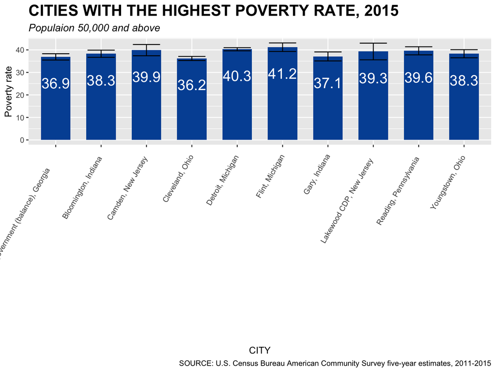

#### Top 10 poorest cities in 2020

These were the poorest cities in the U.S. in 2020. Note that the poverty rate for all of them is lower than it was in 2015.

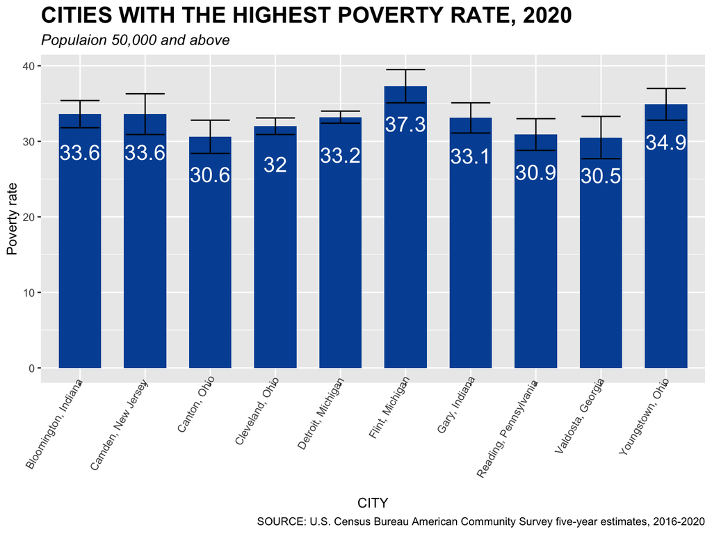

I hope you find this useful. If you have questions about the data feel free to leave a comment or email me: adam (at) adam-richter dot com.